# ATACseq in Bioconductor exercises (part 2)

Rockefeller University, Bioinformatics Resource Centre

https://rockefelleruniversity.github.io/RU_ATACseq/

In todays session we will work with some of the ATAC-seq data of T-regulatory cells from Christina Leslie’s lab.

Aligned data as a BAM file [can be found here.](https://www.encodeproject.org/files/ENCFF053CGD/@@download/ENCFF053CGD.bam)

The peak calls for ATAC-seq data [can be found here](https://www.encodeproject.org/files/ENCFF520GRD/@@download/ENCFF520GRD.bed.gz)

## ATAC-seq analysis

1. Plot the nucleosome free abd mono-nucleosome signals over mouse genome mm10 TSS regions from the T-reg ATAC-seq data for chromosomes chr1 to chr19.

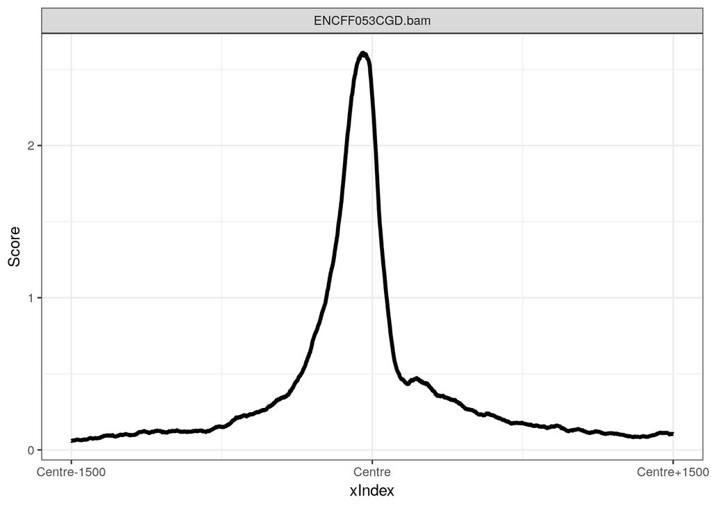

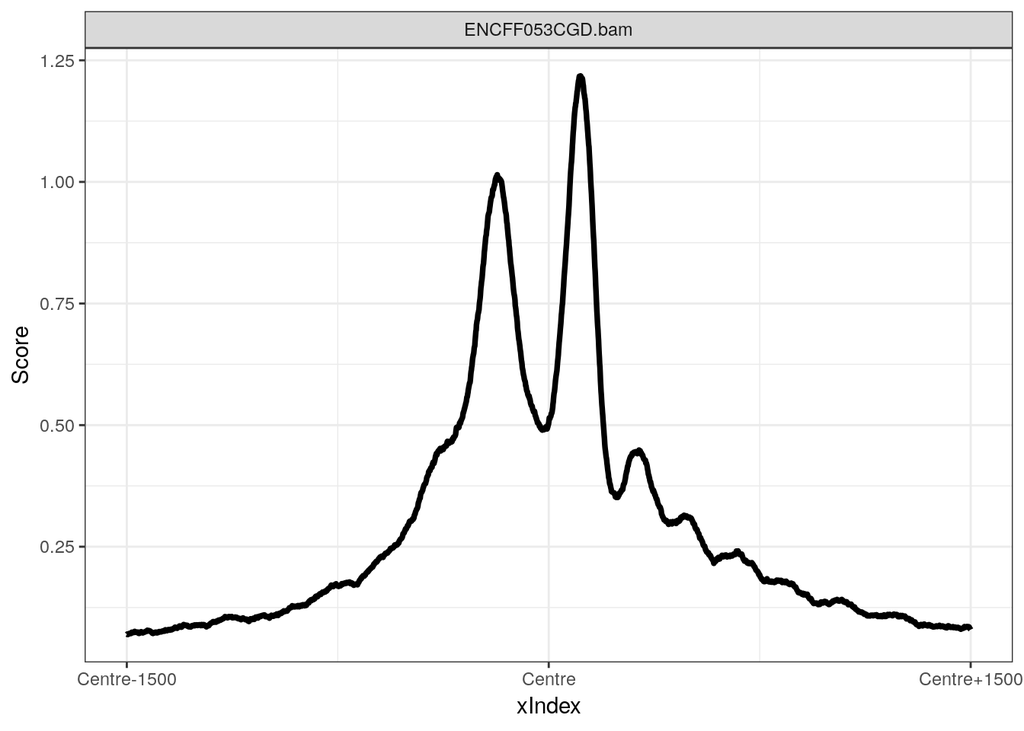

```r
library(soGGi)
library(ggplot2)
library(TxDb.Mmusculus.UCSC.mm10.knownGene)
genesLocations <- genes(TxDb.Mmusculus.UCSC.mm10.knownGene)
tssLocations <- resize(genesLocations,fix="start",width = 1)
tssLocations <- tssLocations[seqnames(tssLocations) %in% paste0("chr",1:19)]

sortedBAM <- "~/Downloads/ENCFF053CGD.bam"
indexBam(sortedBAM)

nucFree <- regionPlot(bamFile = sortedBAM,
                        testRanges = tssLocations,
                        style = "point",
                        format="bam",
                        paired=TRUE,
                        minFragmentLength = 0,
                        maxFragmentLength = 100,
                        forceFragment = 50)

monoNuc <- regionPlot(bamFile = sortedBAM,
                        testRanges = tssLocations,
                        style = "point",
                        format="bam",
                        paired=TRUE,
                        minFragmentLength = 180,
                      maxFragmentLength = 240,
                      forceFragment = 80)
plotRegion(nucFree)+theme_bw()
plotRegion(monoNuc)+theme_bw()
```

2. Extract the FRIP and Duplication rate for the Encode T-reg ATAC-seq BAM and associated peaks for chromosome 10.

```r
library(ChIPQC)
library(rtracklayer)
openRegionPeaks <- "~/Downloads/ENCFF520GRD.bed.gz"

qcRes <- ChIPQCsample(sortedBAM,
                      peaks = openRegionPeaks,
                      annotation ="mm10",
                      chromosomes = "chr10",
                      verboseT = FALSE)


myMetrics <- QCmetrics(qcRes)
myMetrics[c("RiP%")]
flgCounts <- flagtagcounts(qcRes)
DupRate <- flgCounts["DuplicateByChIPQC"]/flgCounts["Mapped"]
DupRate*100
```

```r
load(file="data/chipqc_Treg.RData")
myMetrics <- QCmetrics(qcRes)
myMetrics[c("RiP%")]
```

```
## RiP%
## 43.9
```

```r
flgCounts <- flagtagcounts(qcRes)
DupRate <- flgCounts["DuplicateByChIPQC"]/flgCounts["Mapped"]
DupRate*100
```

```
## DuplicateByChIPQC
##          6.743219
```

3. For the Treg data produce a plot of transposase cut-sites for nucleosome free fragments around CTCF motifs on chromosome 18. Use the motif “Hsapiens-JASPAR_2014-CTCF-MA0139.1” from MotifDB package.

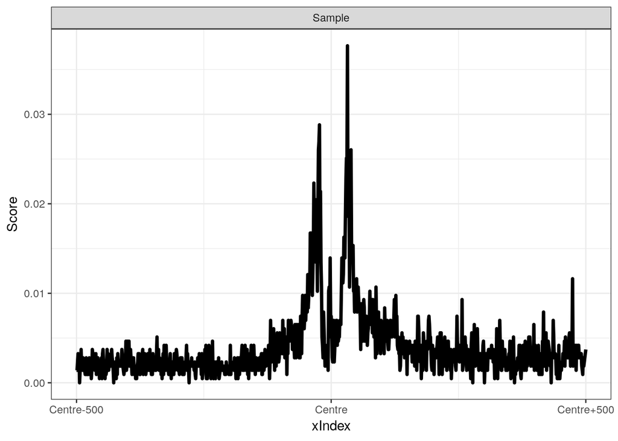

```r
sortedBAM <- "~/Downloads/ENCFF053CGD.bam"
chrLens <- seqlengths(BamFile(sortedBAM))
param=ScanBamParam(flag=scanBamFlag(isProperPair =TRUE),
                    what=c("qname","mapq","isize"),
                   which=GRanges("chr18", IRanges(1,chrLens["chr18"])))
atacReads <- readGAlignmentPairs(sortedBAM,param = param)
insertSizes <- abs(elementMetadata(GenomicAlignments::first(atacReads))$isize)
atacReads_Open <- atacReads[insertSizes < 100]
read1 <- GenomicAlignments::first(atacReads_Open)
read2 <- second(atacReads_Open)
Firsts <- resize(granges(read1),fix="start",1)
First_Pos_toCut <- shift(granges(Firsts[strand(read1) == "+"]),
                                         4)
First_Neg_toCut <- shift(granges(Firsts[strand(read1) == "-"]),
                                         -5)

Seconds <- resize(granges(read2),fix="start",1)
Second_Pos_toCut <- shift(granges(Seconds[strand(read2) == "+"]),
                                4)
Second_Neg_toCut <- shift(granges(Seconds[strand(read2) == "-"]),
                                -5)

test_toCut <- c(First_Pos_toCut,First_Neg_toCut,
                Second_Pos_toCut,Second_Neg_toCut)
cutsCoverage <- coverage(test_toCut)
cutsCoverage18 <- cutsCoverage["chr18"]

library(MotifDb)
library(Biostrings)
library(BSgenome.Mmusculus.UCSC.mm10)
CTCF <- query(MotifDb, c("CTCF"))
ctcfMotif <- CTCF[["Hsapiens-JASPAR_2014-CTCF-MA0139.1"]]
myRes <- matchPWM(ctcfMotif,BSgenome.Mmusculus.UCSC.mm10[["chr18"]])
toCompare <- GRanges("chr18",ranges(myRes))
CTCF_Cuts_open <- regionPlot(cutsCoverage18,
                         testRanges = toCompare,
                         style = "point",
                         format="rlelist",distanceAround = 500)

plotRegion(CTCF_Cuts_open)+theme_bw()
```

4. Load the counts for ENCODE Kidney, Liver and Hindbrain. Identify ATACseq sites significantly higher in Liver compared to Hindbrain (padj < 0.05 and padj is not NA) and perform a functional enrichment test using RGreat to identify BioCyc Pathways enriched in these sites.

Counts are in *data/myCounts.RData**

```r
library(DESeq2)
load("data/myCounts.RData")

Group <- factor(c("HindBrain","HindBrain","Kidney","Kidney",
                  "Liver","Liver"))
metaData <- data.frame(Group,row.names=colnames(myCounts))

atacDDS <- DESeqDataSetFromMatrix(assay(myCounts),
                                  metaData,
                                  ~Group,
                                  rowRanges=rowRanges(myCounts))
atacDDS <- DESeq(atacDDS)
```

```
## -- note: fitType='parametric', but the dispersion trend was not well captured by the
##    function: y = a/x + b, and a local regression fit was automatically substituted.
##    specify fitType='local' or 'mean' to avoid this message next time.
```

```r
LiverMinusHindbrain <- results(atacDDS,
                                c("Group","Liver","HindBrain"),
                               format="GRanges")
LiverMinusHindbrain <- LiverMinusHindbrain[
                                order(LiverMinusHindbrain$pvalue)
                         ]
LiverMinusHindbrain <- LiverMinusHindbrain[
                          (!is.na(LiverMinusHindbrain$padj)
                           & LiverMinusHindbrain$padj < 0.05)
                          & LiverMinusHindbrain$log2FoldChange > 0]

library(rGREAT)
great_Job <- submitGreatJob(LiverMinusHindbrain, species = "mm10",request_interval=1,version = "3.0.0")
availableCategories(great_Job)
```

```
## [1] "GO"                               "Phenotype Data and Human Disease"
## [3] "Pathway Data"                     "Gene Expression"
## [5] "Regulatory Motifs"                "Gene Families"
```

```r
great_ResultTable = getEnrichmentTables(great_Job, category = "Pathway Data")
```

```
## The default enrichment tables contain no associated genes for the input
## regions. You can set `download_by = 'tsv'` to download the complete
## table, but note only the top 500 regions can be retreived. See the
## following link:
##
## https://great-help.atlassian.net/wiki/spaces/GREAT/pages/655401/Export#Export-GlobalExport
```

```r
names(great_ResultTable)
```

```
## [1] "PANTHER Pathway" "BioCyc Pathway"  "MSigDB Pathway"
```

```r
great_ResultTable[["BioCyc Pathway"]][1:4, ]
```

```
##             ID
## 1     PWY-5920
## 2     PWY-5189
## 3 PWY3DJ-11470
## 4     PWY-6358
##                                                                     name
## 1                                                   heme biosynthesis II
## 2                                           tetrapyrrole biosynthesis II
## 3                     sphingosine and sphingosine-1-phosphate metabolism
## 4 superpathway of D-<i>myo</i>-inositol (1,4,5)-trisphosphate metabolism
##   Binom_Genome_Fraction Binom_Expected Binom_Observed_Region_Hits
## 1          2.378908e-04      2.3282380                         26
## 2          9.254901e-05      0.9057772                         14
## 3          5.385445e-04      5.2707350                         25
## 4          4.999543e-04      4.8930530                         23
```

[output cut: 20 more lines]